# Explore_bikeshare_data

### Explore Bike Share Data

##### Note : All Images and infographics used in this notebook is created by me

[figure not shown]

```r
# Import ggplot2
library(ggplot2)
```

```r
# Import csv files
ny = read.csv('new_york_city.csv')
wash = read.csv('washington.csv')
chi = read.csv('chicago.csv')
```

```r
head(ny)
```

| X | Start.Time | End.Time | Trip.Duration | Start.Station | End.Station | User.Type | Gender | Birth.Year |
| --- | --- | --- | --- | --- | --- | --- | --- | --- |
| 5688089 | 2017-06-11 14:55:05 | 2017-06-11 15:08:21 | 795 | Suffolk St & Stanton St | W Broadway & Spring St | Subscriber | Male | 1998 |
| 4096714 | 2017-05-11 15:30:11 | 2017-05-11 15:41:43 | 692 | Lexington Ave & E 63 St | 1 Ave & E 78 St | Subscriber | Male | 1981 |
| 2173887 | 2017-03-29 13:26:26 | 2017-03-29 13:48:31 | 1325 | 1 Pl & Clinton St | Henry St & Degraw St | Subscriber | Male | 1987 |
| 3945638 | 2017-05-08 19:47:18 | 2017-05-08 19:59:01 | 703 | Barrow St & Hudson St | W 20 St & 8 Ave | Subscriber | Female | 1986 |
| 6208972 | 2017-06-21 07:49:16 | 2017-06-21 07:54:46 | 329 | 1 Ave & E 44 St | E 53 St & 3 Ave | Subscriber | Male | 1992 |
| 1285652 | 2017-02-22 18:55:24 | 2017-02-22 19:12:03 | 998 | State St & Smith St | Bond St & Fulton St | Subscriber | Male | 1986 |

```r
head(wash)
```

| X | Start.Time | End.Time | Trip.Duration | Start.Station | End.Station | User.Type |
| --- | --- | --- | --- | --- | --- | --- |
| 1621326 | 2017-06-21 08:36:34 | 2017-06-21 08:44:43 | 489.066 | 14th & Belmont St NW | 15th & K St NW | Subscriber |
| 482740 | 2017-03-11 10:40:00 | 2017-03-11 10:46:00 | 402.549 | Yuma St & Tenley Circle NW | Connecticut Ave & Yuma St NW | Subscriber |
| 1330037 | 2017-05-30 01:02:59 | 2017-05-30 01:13:37 | 637.251 | 17th St & Massachusetts Ave NW | 5th & K St NW | Subscriber |
| 665458 | 2017-04-02 07:48:35 | 2017-04-02 08:19:03 | 1827.341 | Constitution Ave & 2nd St NW/DOL | M St & Pennsylvania Ave NW | Customer |
| 1481135 | 2017-06-10 08:36:28 | 2017-06-10 09:02:17 | 1549.427 | Henry Bacon Dr & Lincoln Memorial Circle NW | Maine Ave & 7th St SW | Subscriber |
| 1148202 | 2017-05-14 07:18:18 | 2017-05-14 07:24:56 | 398.000 | 1st & K St SE | Eastern Market Metro / Pennsylvania Ave & 7th St SE | Subscriber |

```r
head(chi)
```

| X | Start.Time | End.Time | Trip.Duration | Start.Station | End.Station | User.Type | Gender | Birth.Year |
| --- | --- | --- | --- | --- | --- | --- | --- | --- |
| 1423854 | 2017-06-23 15:09:32 | 2017-06-23 15:14:53 | 321 | Wood St & Hubbard St | Damen Ave & Chicago Ave | Subscriber | Male | 1992 |
| 955915 | 2017-05-25 18:19:03 | 2017-05-25 18:45:53 | 1610 | Theater on the Lake | Sheffield Ave & Waveland Ave | Subscriber | Female | 1992 |
| 9031 | 2017-01-04 08:27:49 | 2017-01-04 08:34:45 | 416 | May St & Taylor St | Wood St & Taylor St | Subscriber | Male | 1981 |
| 304487 | 2017-03-06 13:49:38 | 2017-03-06 13:55:28 | 350 | Christiana Ave & Lawrence Ave | St. Louis Ave & Balmoral Ave | Subscriber | Male | 1986 |
| 45207 | 2017-01-17 14:53:07 | 2017-01-17 15:02:01 | 534 | Clark St & Randolph St | Desplaines St & Jackson Blvd | Subscriber | Male | 1975 |
| 1473887 | 2017-06-26 09:01:20 | 2017-06-26 09:11:06 | 586 | Clinton St & Washington Blvd | Canal St & Taylor St | Subscriber | Male | 1990 |

### Question 1

**Most Common Trip Duration In New York City.**

[figure not shown]

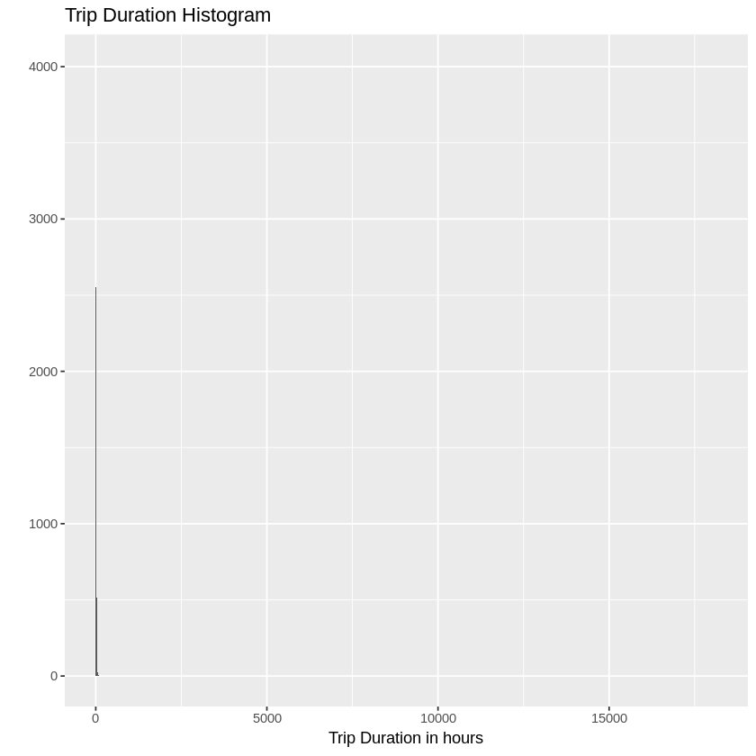

```r
# Create Histogram for Trips Duration
qplot(x =Trip.Duration/60 , data = ny , binwidth =1 )+
xlab('Trip Duration in hours') +
ggtitle('Trip Duration Histogram')
```

```r
table(ny$Trip.Duration)/60
```

[output not shown]

[output cut: 913 more lines]

[output not shown]

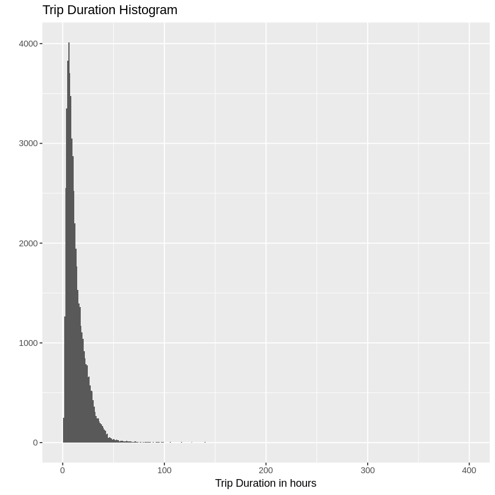

```r
# Create Histogram for Trips Duration (scaled)
qplot(x =Trip.Duration/60 , data = ny , binwidth =1 )+
xlab('Trip Duration in hours') +
ggtitle('Trip Duration Histogram') +
scale_x_continuous(limits = c(0,400))
```

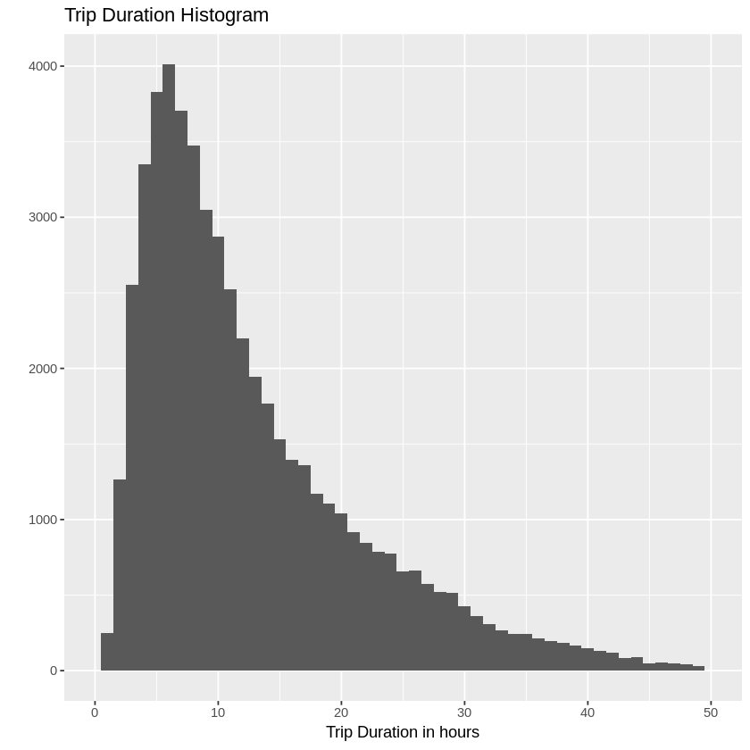

```r
# Create Histogram for Trips Duration (scaled)
qplot(x =Trip.Duration/60 , data = ny , binwidth =1 )+
xlab('Trip Duration in hours') +
ggtitle('Trip Duration Histogram') +
scale_x_continuous(limits = c(0,50))
```

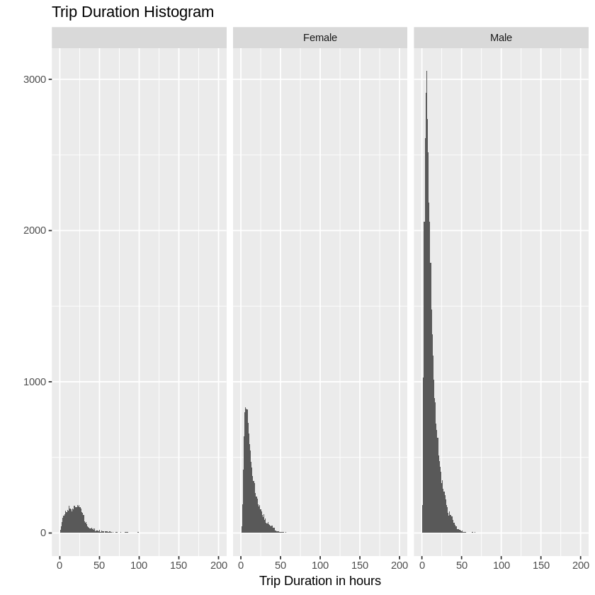

```r
# Create Histogram for Trips Duration (scaled)
qplot(x =Trip.Duration/60 , data = subset(ny,!is.na(Gender)) , binwidth =1 )+
scale_x_continuous(limits = c(0,200)) +
xlab('Trip Duration in hours') +
ggtitle('Trip Duration Histogram') +
facet_wrap('Gender')
```

### 2. All Male Histogram have nearly the highest trends

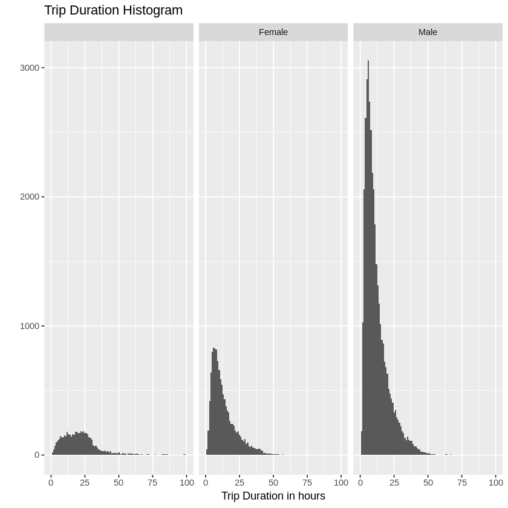

```r
# Create Histogram for Trips Duration (scaled)
qplot(x =Trip.Duration/60 , data = subset(ny,!is.na(Gender)) , binwidth =1 )+
scale_x_continuous(limits = c(0,100)) +
xlab('Trip Duration in hours') +
ggtitle('Trip Duration Histogram') +
facet_wrap('Gender')
```

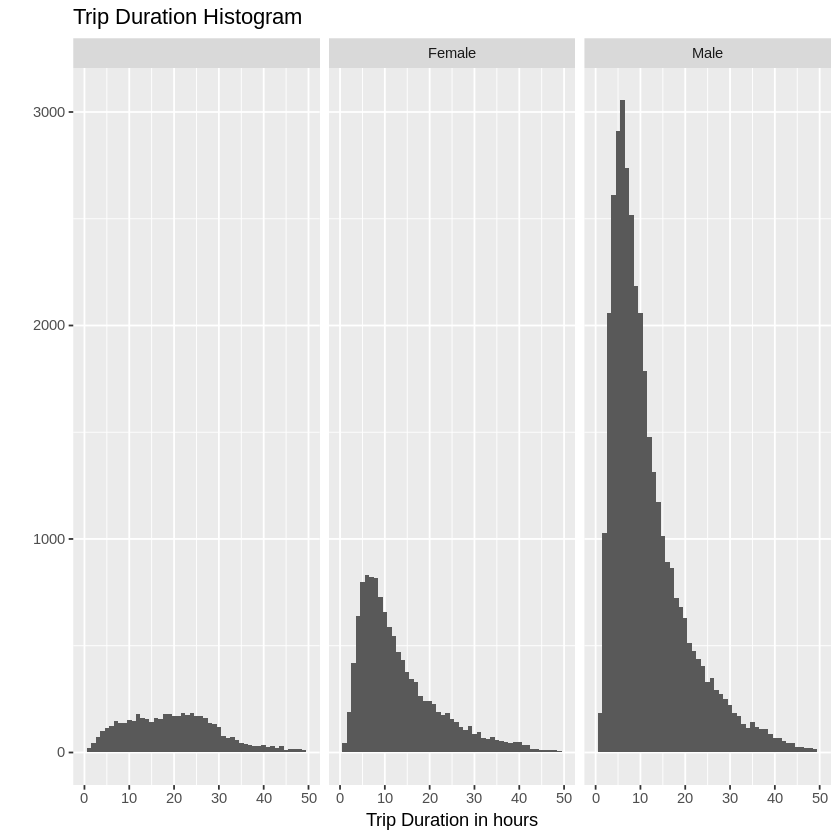

```r
# Create Histogram for Trips Duration (scaled)
qplot(x =Trip.Duration/60 , data = subset(ny,!is.na(Gender)) , binwidth =1 )+
scale_x_continuous(limits = c(0,50)) +
xlab('Trip Duration in hours') +
ggtitle('Trip Duration Histogram') +
facet_wrap('Gender')
```

```r
by(ny$Trip.Duration/60,ny$Gender, summary)
```

```
ny$Gender:
    Min.  1st Qu.   Median     Mean  3rd Qu.     Max.     NA's
   1.033   12.300   20.533   31.536   28.483 8256.900        1
------------------------------------------------------------
ny$Gender: Female
    Min.  1st Qu.   Median     Mean  3rd Qu.     Max.
   1.017    6.667   10.733   14.600   17.800 1298.633
------------------------------------------------------------
ny$Gender: Male
     Min.   1st Qu.    Median      Mean   3rd Qu.      Max.
    1.017     5.667     9.183    12.815    15.300 18143.900
```

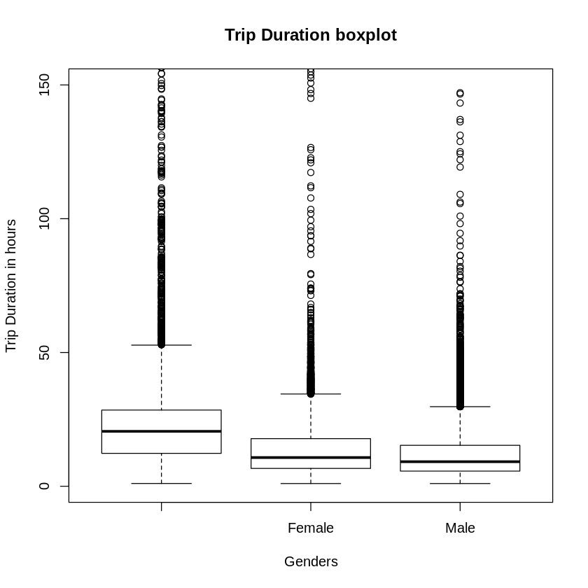

```r
# Create boxplot for Trips Duration

boxplot(Trip.Duration/60~Gender,data=subset(ny,!is.na(Gender)), main="Trip Duration boxplot",
   xlab="Genders", ylab="Trip Duration in hours" , ylim = c(0,150) )
```

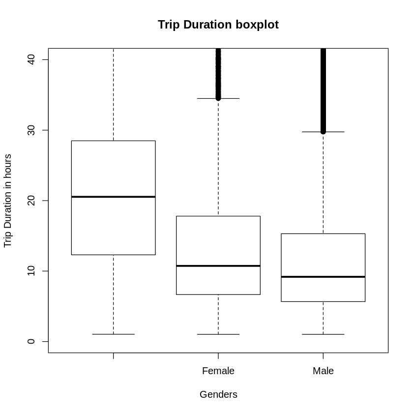

```r
# Create boxplot for Trips Duration (scaled)

boxplot(Trip.Duration/60~Gender,data=subset(ny,!is.na(Gender)), main="Trip Duration boxplot",
   xlab="Genders", ylab="Trip Duration in hours" , ylim = c(0,40) )
```

### Females has slightly higher duration times than males (Can be examined from above boxplots)

### Question 2

**Most Common Year , Month , Day , Hour , Minute.**

[figure not shown]

```r
# Create Year Column
ny$Yr <- format(as.Date(ny$Start.Time), "%Y")
```

```r
table(ny$Yr)
```

```
 2017
54770
```

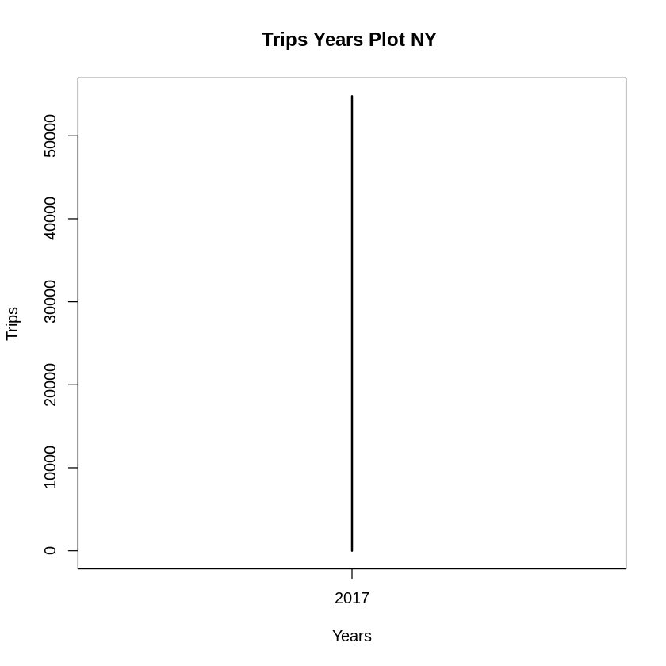

```r
# plot Year Column
plot(table(ny$Yr),ylab = 'Trips' , xlab= 'Years' ,main = 'Trips Years Plot NY ')
```

```r
# Create Year Column
wash$Yr <- format(as.Date(wash$Start.Time), "%Y")
```

```r
table(wash$Yr)
```

```
 2017
89050
```

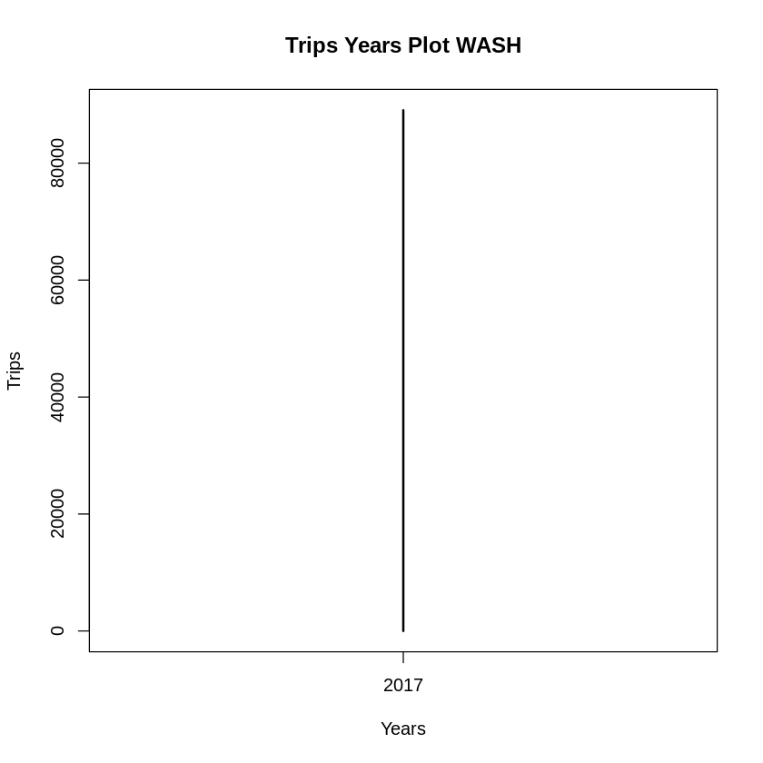

```r
# plot Year Column
plot(table(wash$Yr),ylab = 'Trips' , xlab= 'Years',main = 'Trips Years Plot WASH')
```

```r
# Create Year Column
chi$Yr <- format(as.Date(chi$Start.Time), "%Y")
```

```r
table(chi$Yr)
```

```
2017
8630
```

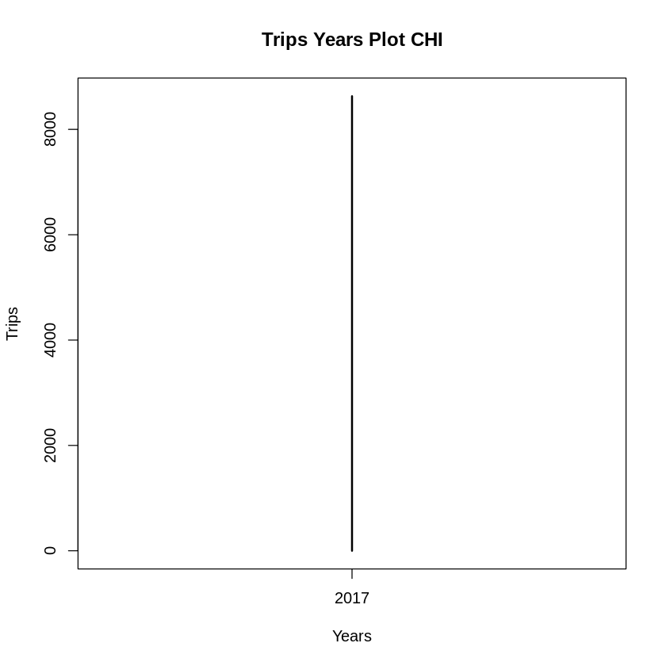

```r
# plot Year Column
plot(table(chi$Yr),ylab = 'Trips' , xlab= 'Years',main = 'Trips Years Plot CHI')
```

### The Most Common Year was 2017

#### Trivialy Because it is the Only Year

```
   01    02    03    04    05    06
 5745  6364  5820 10661 12180 14000
```

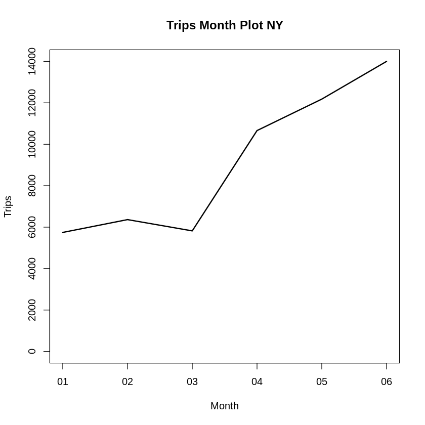

```r
# Create Month Column and line Plot it

ny$month <- format(as.Date(ny$Start.Time), "%m")

table(ny$month)

plot(table(ny$month),ylab = 'Trips' , xlab= 'Month','l',main = 'Trips Month Plot NY')
```

```
   01    02    03    04    05    06
 8946 11563 12612 18522 17072 20335
```

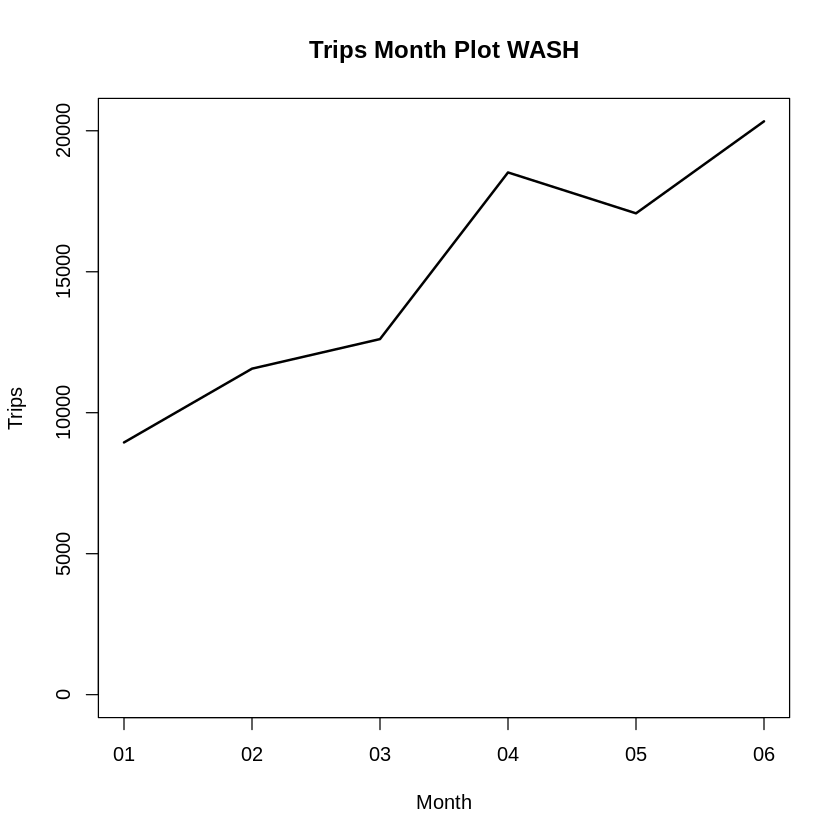

```r
# Create Month Column and line Plot it

wash$month <- format(as.Date(wash$Start.Time), "%m")

table(wash$month)

plot(table(wash$month),ylab = 'Trips' , xlab= 'Month','l',main = 'Trips Month Plot WASH')
```

```
  01   02   03   04   05   06
 650  930  803 1526 1905 2816
```

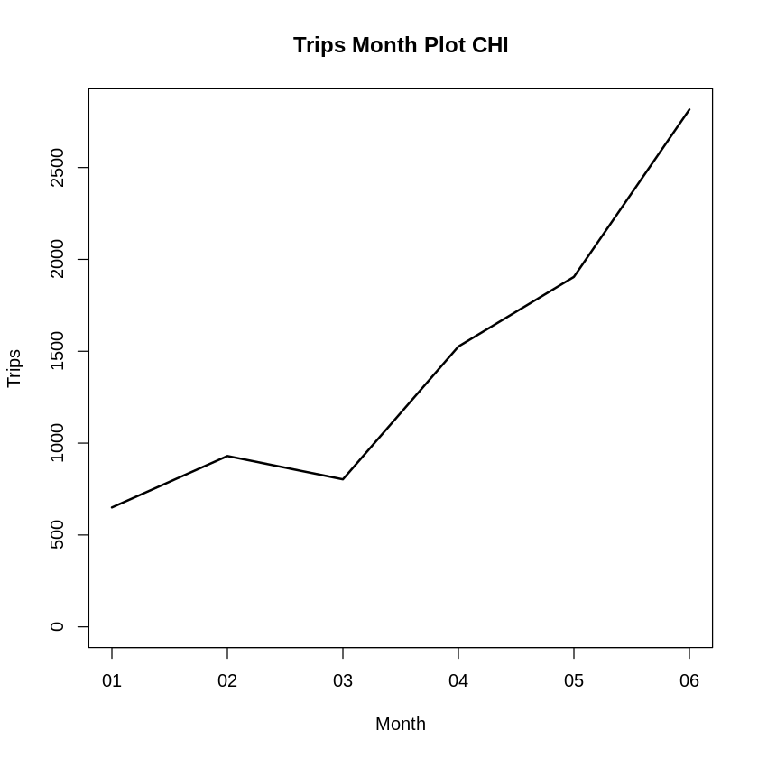

```r
# Create Month Column and line Plot it

chi$month <- format(as.Date(chi$Start.Time), "%m")

table(chi$month)

plot(table(chi$month),ylab = 'Trips' , xlab= 'Month' , 'l' ,main = 'Trips Month Plot CHI')
```

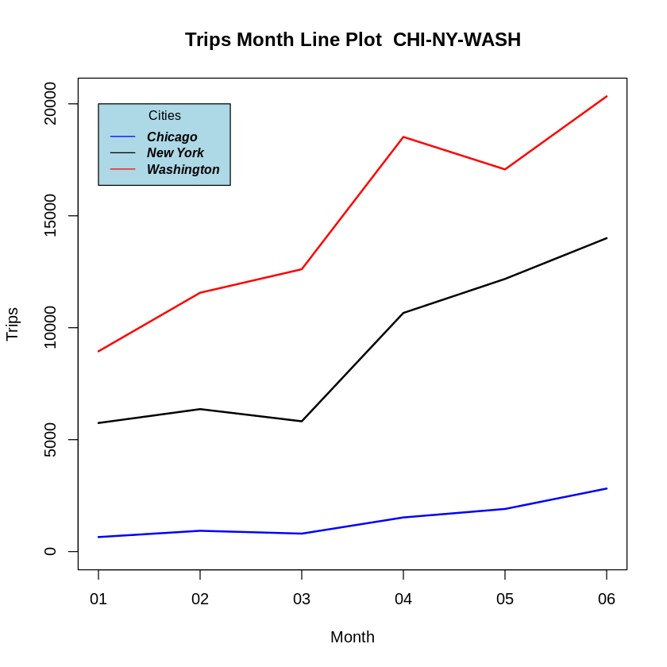

```r
#Plot Month Line plots from all cities

plot(table(wash$month),ylab = 'Trips' , xlab= 'Month',col="red",'l',main = 'Trips Month Line Plot  CHI-NY-WASH')
lines(table(ny$month),ylab = 'Trips' , xlab= 'Month',type = "l")
points(table(chi$month),ylab = 'Trips' , xlab= 'Month',col="blue",type = "l")
legend(1, 20000, legend=c("Chicago", "New York","Washington"),
       col=c("blue" ,"black" ,"red"), lty=c(1,1), cex=0.8,
       title="Cities", text.font=4, bg='lightblue')
```

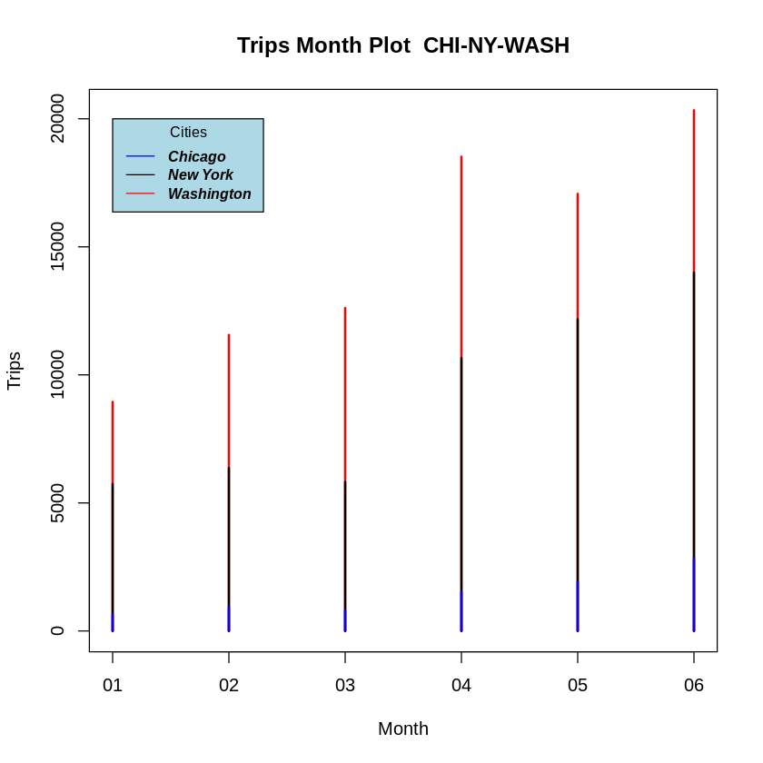

```r
# Plot Month from all cities

plot(table(wash$month),ylab = 'Trips' , xlab= 'Month',col="red",main = 'Trips Month Plot  CHI-NY-WASH')
lines(table(ny$month),ylab = 'Trips' , xlab= 'Month')
points(table(chi$month),ylab = 'Trips' , xlab= 'Month',col="blue")
legend(1, 20000, legend=c("Chicago", "New York","Washington"),
       col=c("blue" ,"black" ,"red"), lty=c(1,1), cex=0.8,
       title="Cities", text.font=4, bg='lightblue')
```

### The Most Common Month was June (06)

#### Chicago has least number of trips in each month followed by New York then in first place it is Washington

```
  01   02   03   04   05   06   07   08   09   10   11   12   13   14   15   16
1972 1975 1889 1563 1594 1563 1519 1867 1792 1695 1823 1927 1633 1605 1686 1760
  17   18   19   20   21   22   23   24   25   26   27   28   29   30   31
1656 1850 1831 1876 2107 1634 2045 2096 1568 1847 2119 2068 1684 1782  744
```

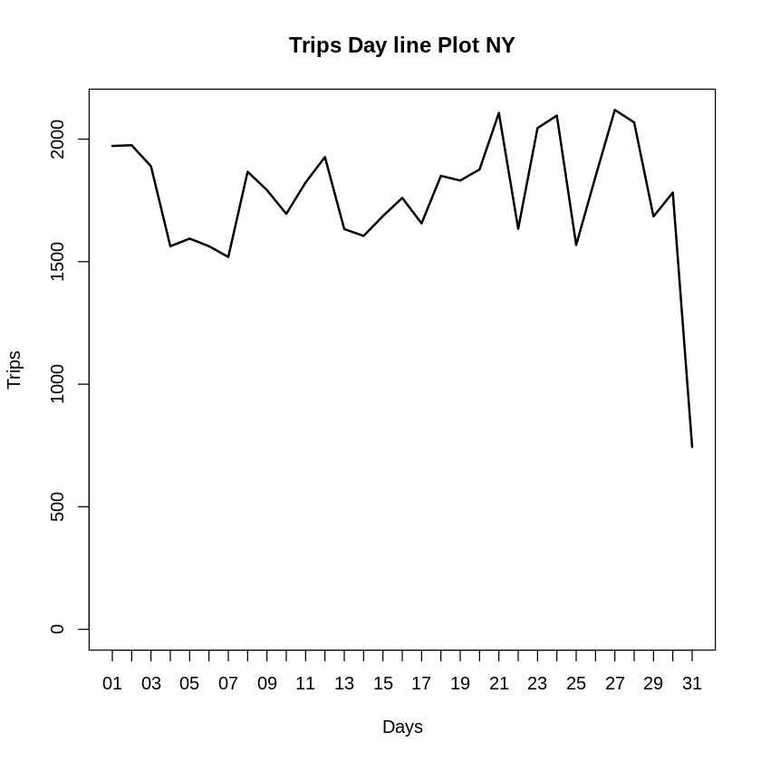

```r
#Create Day Column and line Plot it


ny$day <- format(as.Date(ny$Start.Time), "%d")
table(ny$day)
plot(table(ny$day),xlab = 'Days' ,ylab= 'Trips','l',main = 'Trips Day line Plot NY')
```

```
 01  02  03  04  05  06  07  08  09  10  11  12  13  14  15  16  17  18  19  20
226 233 271 235 200 263 248 297 307 274 259 250 297 228 335 292 318 368 280 301
 21  22  23  24  25  26  27  28  29  30  31
328 324 304 331 315 278 341 326 230 238 133
```

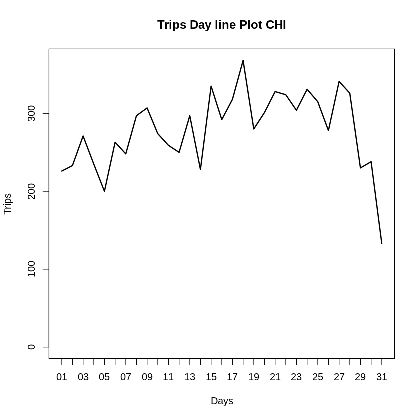

```r
#Create Day Column and line Plot it
chi$day <- format(as.Date(chi$Start.Time), "%d")
table(chi$day)
plot(table(chi$day),xlab = 'Days' , ylab= 'Trips','l',main = 'Trips Day line Plot CHI')
```

```
  01   02   03   04   05   06   07   08   09   10   11   12   13   14   15   16
2788 2976 2811 2741 2584 2457 2586 3083 3312 2989 2585 2679 2971 2652 3002 2672
  17   18   19   20   21   22   23   24   25   26   27   28   29   30   31
2800 3254 3141 3343 3346 2546 2864 3075 3123 3132 3457 3203 3047 2691 1140
```

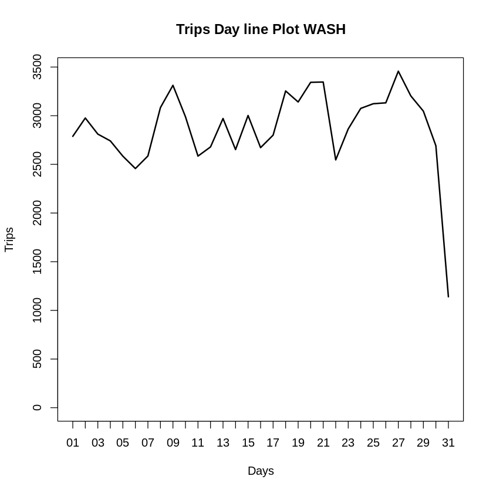

```r
#Create Day Column and line Plot it
wash$day <- format(as.Date(wash$Start.Time), "%d")
table(wash$day)
plot(table(wash$day),xlab = 'Days' , ylab= 'Trips','l',main = 'Trips Day line Plot WASH')
```

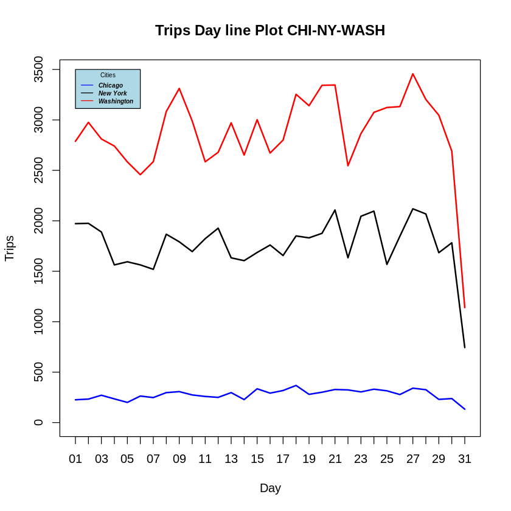

```r
#Plot Day Line plots from all cities
plot(table(wash$day),ylab = 'Trips' , xlab= 'Day',col="red" ,'l',main = 'Trips Day line Plot CHI-NY-WASH')
lines(table(ny$day),ylab = 'Trips' , xlab= 'Day',type = 'l')
points(table(chi$day),ylab = 'Trips' , xlab= 'Day',col="blue",type = 'l')
legend(1, 3500, legend=c("Chicago", "New York","Washington"),
       col=c("blue" ,"black" ,"red"), lty=c(1,1), cex=0.5,
       title="Cities", text.font=4, bg='lightblue')
```

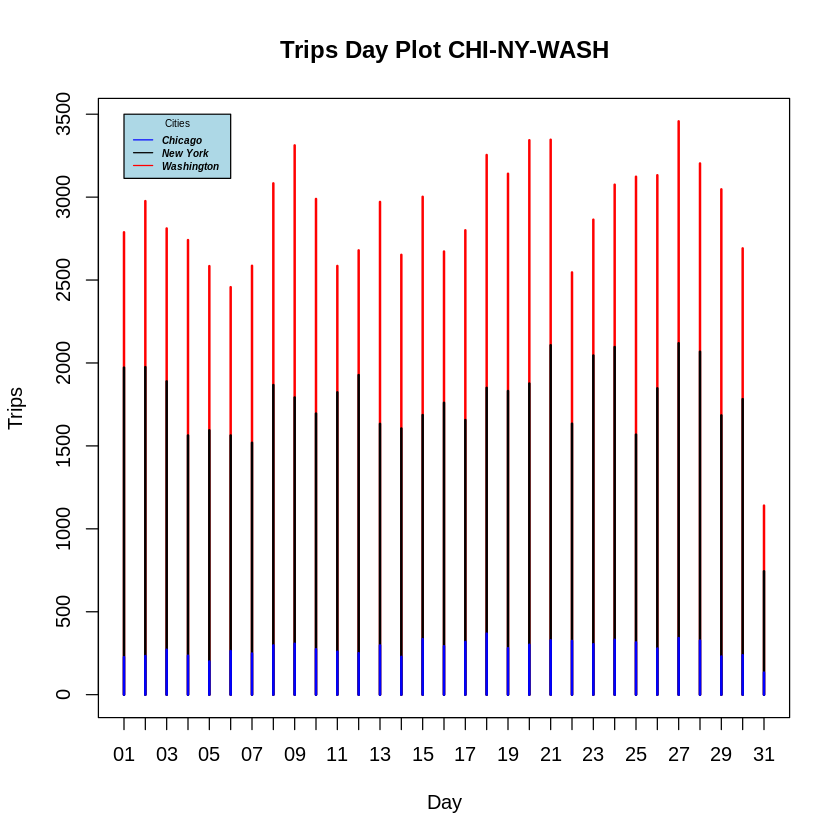

```r
#Plot Day from all cities
plot(table(wash$day),ylab = 'Trips' , xlab= 'Day',col="red",main = 'Trips Day Plot CHI-NY-WASH')
lines(table(ny$day),ylab = 'Trips' , xlab= 'Day')
points(table(chi$day),ylab = 'Trips' , xlab= 'Day',col="blue")
legend(1, 3500, legend=c("Chicago", "New York","Washington"),
       col=c("blue" ,"black" ,"red"), lty=c(1,1), cex=0.5,
       title="Cities", text.font=4, bg='lightblue')
```

#### Chicago has least number of trips in each day followed again by New York then in first place it is Washington

```r
#Create hour-minute Column and  Plot it
ny$hour_minute <- format(as.POSIXct(ny$Start.Time), "%H:%M")
```

```r
table(ny$hour_minute)
```

[output not shown]

[output cut: 161 more lines]

[output not shown]

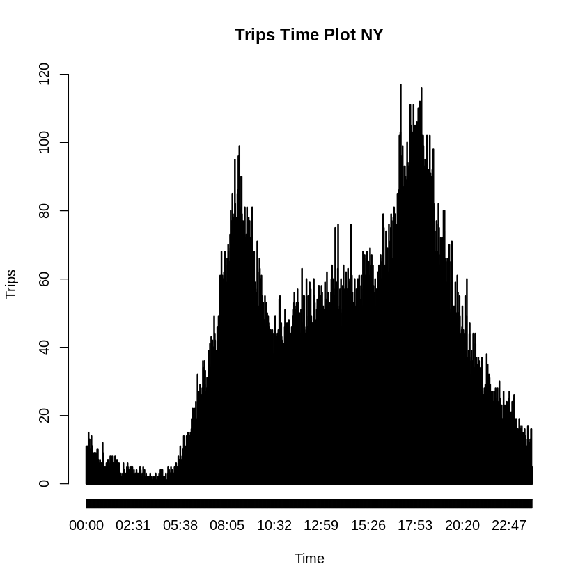

```r
plot(table(ny$hour_minute),xlab = 'Time' ,ylab= 'Trips',main = 'Trips Time Plot NY')
```

```r
#Create hour-minute Column and  Plot it
chi$hour_minute <- format(as.POSIXct(chi$Start.Time), "%H:%M")
```

```r
table(chi$hour_minute)
```

[output not shown]

[output cut: 129 more lines]

[output not shown]

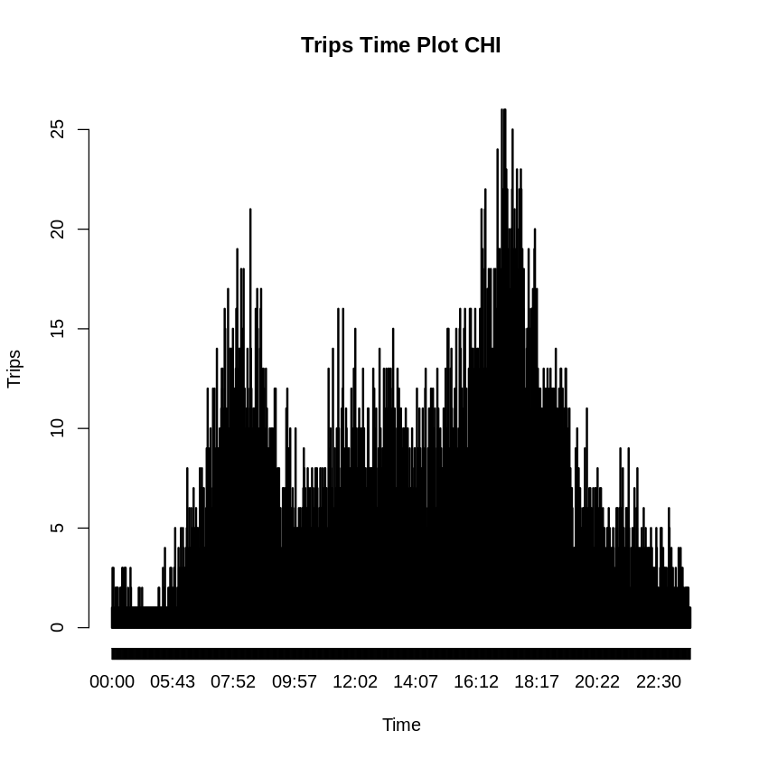

```r
plot(table(chi$hour_minute),xlab = 'Time' , ylab= 'Trips',main = 'Trips Time Plot CHI')
```

Note : I tried to Analyze the Time too for Washington but I recieved error I could not solve : character string is not in a standard unambiguous format

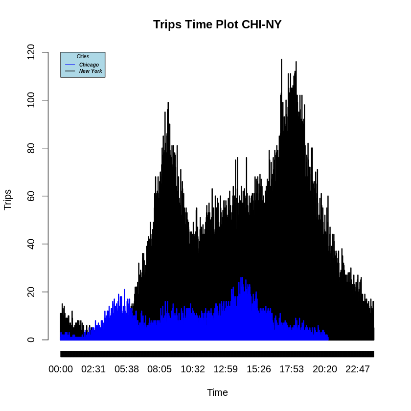

```r
#Create Plot for hour-minute Column for chicago and NY
plot(table(ny$hour_minute),xlab = 'Time' ,ylab= 'Trips',main = 'Trips Time Plot CHI-NY')
points(table(chi$hour_minute),ylab = 'Trips' , xlab= 'Day',col="blue",main = 'Trips Time Plot')
legend(1, 120, legend=c("Chicago","New York"),
       col=c("blue" ,"black"), lty=c(1,1), cex=0.5,
       title="Cities", text.font=4, bg='lightblue')
```

### Question 3

**Most Common User Type**

```r
# Get User Types Value count
table(ny$User.Type)
```

```
             Customer Subscriber
       119       5558      49093
```

```r
# Get User Types Value count %
table(ny$User.Type)/length(ny$User.Type)*100
```

```
             Customer Subscriber
 0.2172722 10.1478912 89.6348366
```

```r
# Create dataframe for pie chart
NY_Pie <- data.frame((table(ny$User.Type)/length(ny$User.Type))*100 ,class = c("Unkonwn", "Customer","Subscriber"))
```

```r
# Create only 2 decimal numbers for labeling the pie chart
count = 0
Percentage = list()
for (i in table(ny$User.Type)/length(ny$User.Type)*100 ) {
    count = count + 1
Percentage[count] <- (format(round(i, 2), nsmall = 2))
}
```

[figure not shown]

```r
# Create piechart
ggplot(NY_Pie, aes(x="", y=Freq, fill=class)) +
  geom_bar(stat="identity", width=1, color="white") +
  coord_polar("y", start=0) +
  geom_text(aes(label = Percentage),
            position = position_stack(vjust = 0.5)) +
ylab('User Type Distribution NY') +
ggtitle('User Type Pie Chart NY')
```

```r
# Create dataframe for pie chart
table(chi$User.Type)
```

```
             Customer Subscriber
         1       1746       6883
```

```r
# Get User Types Value count %
table(chi$User.Type)/length(chi$User.Type)*100
```

```
               Customer  Subscriber
 0.01158749 20.23174971 79.75666280
```

```r
# Create dataframe for pie chart
CHI_Pie <- data.frame((table(chi$User.Type)/length(chi$User.Type))*100 ,class = c("Unkonwn", "Customer","Subscriber"))
```

```r
# Create only 2 decimal numbers for labeling the pie chart
count = 0
Percentage = list()
for (i in table(chi$User.Type)/length(chi$User.Type)*100 ) {
    count = count + 1
Percentage[count] <- (format(round(i, 2), nsmall = 2))
}
```

[figure not shown]

```r
# Create piechart
ggplot(CHI_Pie, aes(x="", y=Freq, fill=class)) +
  geom_bar(stat="identity", width=1, color="white") +
  coord_polar("y", start=0) +
  geom_text(aes(label = Percentage),
            position = position_stack(vjust = 0.5))+
ylab('User Type Distribution CHI') +
ggtitle('User Type Pie Chart CHI')
```

```r
# Create dataframe for pie chart
table(wash$User.Type)
```

```
             Customer Subscriber
         1      23450      65600
```

```r
# Get User Types Value count %
table(wash$User.Type)/length(wash$User.Type)*100
```

```
                 Customer   Subscriber
 0.001122952 26.333224781 73.665652267
```

```r
# Create dataframe for pie chart
WASH_Pie <- data.frame((table(wash$User.Type)/length(wash$User.Type))*100 ,class = c("Unkonwn", "Customer","Subscriber"))
```

```r
# Create only 2 decimal numbers for labeling the pie chart

count = 0
Percentage = list()
for (i in table(wash$User.Type)/length(wash$User.Type)*100 ) {
    count = count + 1
Percentage[count] <- (format(round(i, 2), nsmall = 2))
}
```

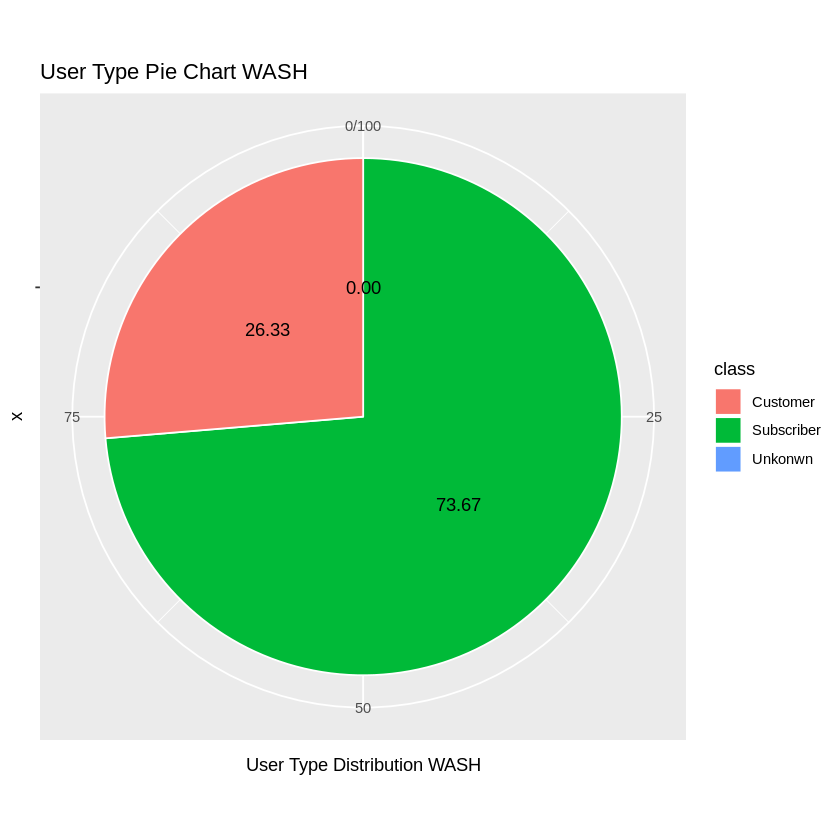

```r
# Create piechart
ggplot(WASH_Pie, aes(x="", y=Freq, fill=class)) +
  geom_bar(stat="identity", width=1, color="white") +
  coord_polar("y", start=0) +
  geom_text(aes(label = Percentage),
            position = position_stack(vjust = 0.5)) +
ylab('User Type Distribution WASH') +
ggtitle('User Type Pie Chart WASH')
```

### We can see that Subscriber has high Percentage of trips (~73- ~90 %) In Chi , Wash , NY

### We can see that Customers has resonable Percentage of trips (~10- ~27 %) In Chi , Wash , NY

### We can see that Unknown has tiny Percentage of trips (~0.00 - 0.22%) In Chi , Wash , NY

## Finishing Up

> Congratulations! You have reached the end of the Explore Bikeshare Data Project. You should be very proud of all you have accomplished!

> **Tip**: Once you are satisfied with your work here, check over your report to make sure that it is satisfies all the areas of the [rubric](https://review.udacity.com/#!/rubrics/2508/view).

## Directions to Submit

> Before you submit your project, you need to create a .html or .pdf version of this notebook in the workspace here. To do that, run the code cell below. If it worked correctly, you should get a return code of 0, and you should see the generated .html file in the workspace directory (click on the orange Jupyter icon in the upper left).

> Alternatively, you can download this report as .html via the **File** > **Download as** submenu, and then manually upload it into the workspace directory by clicking on the orange Jupyter icon in the upper left, then using the Upload button.

> Once you've done this, you can submit your project by clicking on the "Submit Project" button in the lower right here. This will create and submit a zip file with this .ipynb doc and the .html or .pdf version you created. Congratulations!

```r
system('python -m nbconvert Explore_bikeshare_data.ipynb')
```